# Test di accumulo gravitazionale in acqua (BEST) - scala ridotta

## Obiettivo del test

Verificare in scala, in ambiente di laboratorio **immerso in acqua**, il comportamento del sistema di accumulo gravitazionale (BEST) utilizzando:

- Motore-generatore trifase da **0,6 hp** (≈ 447 W) a **700 rpm**, alimentato a 220 V
- Altezza di caduta **h = 1 m**
- Velocità di discesa **v = 0,1 m/s**
- **Corpo morto** di massa **m = 50 kg**, immerso in acqua

## Allestimento del prototipo

- **Motore-generatore**: trifase 220 V stella, 0,6 hp – 700 rpm, coppia nominale Tₙ ≈ 6,1 N·m.
- **Motoriduttore**: un motoriduttore planetario con rapporto totale ≈ 15 : 1, involucro IP68, lubrificazione a bagno d’olio.
- **Tamburo**: raggio r = 0,3 m; avvolge un cavo Ø 6 mm.
- **Corpo morto**: blocchi in cemento/mattoni (ρ = 2 400 kg/m³), massa m = 50 kg → volume V ≃ 0,021 m³.
- **Ambiente di prova**: il corpo scende immerso in acqua (ρ_acqua = 1 000 kg/m³).
- **Strumentazione**: tachimetro ottico, cella di carico in linea, analizzatore di rete, DAQ 1 kS/s.

## Calcoli meccanici ed energetici in acqua

1. **Forza peso e spinta di Archimede**
   - Forza peso: Fₚ = m·g = 50 × 9,81 ≃ 490,5 N
   - Spinta di Archimede: Fₐ = ρ_acqua·g·V = 1 000 × 9,81 × 0,021 ≃ 206 N
   - **Forza netta**: Fₙₑₜ = Fₚ – Fₐ ≃ 490,5 – 206 ≃ 284,5 N
2. **Rapporto di riduzione**
   - Velocità tamburo lento: si utilizza un singolo motoriduttore **15:1**, ottenendo una velocità minore e coppia adeguata.
3. **Coppia al tamburo lento**
   - Tₛₗₒ𝓌 = Fₙₑₜ × r = 284,5 × 0,3 ≃ 85,3 N·m
   - Coppia al generatore: T_gen = Tₛₗₒ𝓌 / 15 ≃ 5,69 N·m (vicino al nominale 6,1 N·m)
4. **Parametri di ciclo**
   - Altezza h = 1 m
   - Velocità v = 0,1 m/s → tempo t = h / v = 10 s

### Energia potenziale e potenze rigenerate

- Energia potenziale disponibile: Eₚₒₜ = Fₙₑₜ · h = 284,5 N × 1 m ≃ 284,5 J
- Potenza meccanica media: Pₘₑ𝚌ₕ = Eₚₒₜ / t = 284,5 / 10 s ≃ 28,5 W
- Potenza rigenerata (η = 92 %): Pᵣₑ𝗀 = Pₘₑ𝚌ₕ × η
5. **Verifica coppie**
- Albero tamburo (ω ≃ 3,18 rpm ≃ 0,333 rad/s): Tₗ = Pₘₑ𝚌ₕ / ω ≃ 28,5 / 0,333 ≃ 85,5 N·m
- Albero generatore (uso ratio 15:1, ω ≃ 700/15 ≃ 46,7 rpm ≃ 4,89 rad/s): Tₙ = Tₗ / 15 ≃ 5,7 N·m

## Alimentazione e cablaggi

- **Tensione**: 220 V trifase L–L
- **Corrente di linea** (cos φ ≈ 0,8, ηₑₗ ≈ 0,92): I = Pₘₑ𝚌ₕ / (√3·V·cosφ·ηₑₗ)
- **Cavo**: 2,5 mm²
- **Magnetotermico**: 10 A curva C

## Procedura di prova in laboratorio

1. Riempire il serbatoio e verificare le condizioni di immersione del corpo morto.
2. Installare il corpo morto, azzerare cella di carico e tachimetro.
3. Eseguire 10 cicli:
   - Sollevamento controllato a velocità ridotta (≈46,7 rpm al generatore) → 1 m in 10 s.
   - Mantenimento 5 s in alto.
   - Inversione e discesa controllata, acquisire potenza rigenerata.

## Dati test

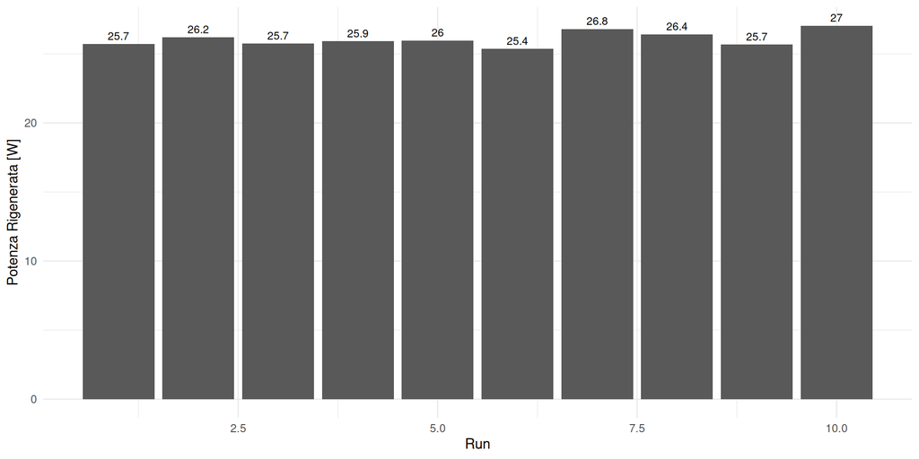

Potenza rigenerata su 10 discese con 50 kg in acqua